# Question 2: Currency Hedging Analysis

Vincent Reinshagen

November 2024

This plot recreates the plot from the study and clearly shows the negative correlation between the global allocation and the Rand

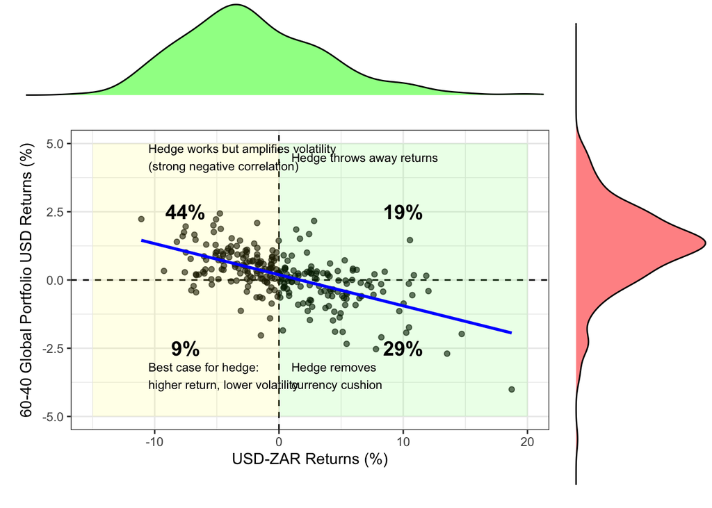

The density plot shows that, while hedging increases average returns, it also introduces greater variability. This aligns with the notion that unhedged portfolios benefit from the rand’s typical negative correlation with global returns, resulting in more consistent outcomes, whereas hedged portfolios might generate higher returns but at the cost of increased exposure to volatility.

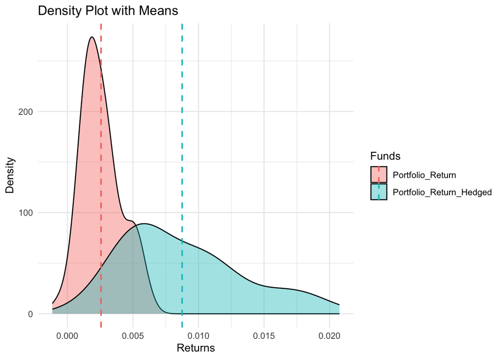

The variance density plot displays the benefit of the negative correlation between the rand and offshore asset returns, which acts as a volatility dampener. In contrast, the hedged portfolio, shown in blue, exhibits a broader variance distribution with a higher mean variance marked by the blue dashed line. This suggests that hedging removes the natural volatility reduction provided by the rand’s movements, leading to increased overall portfolio variance. The data underscores that unhedged portfolios leverage the rand’s volatility to reduce risk, while systematic hedging increases volatility, supporting the conclusion that currency hedging should be employed tactically for short-term adjustments rather than as a long-term strategy.

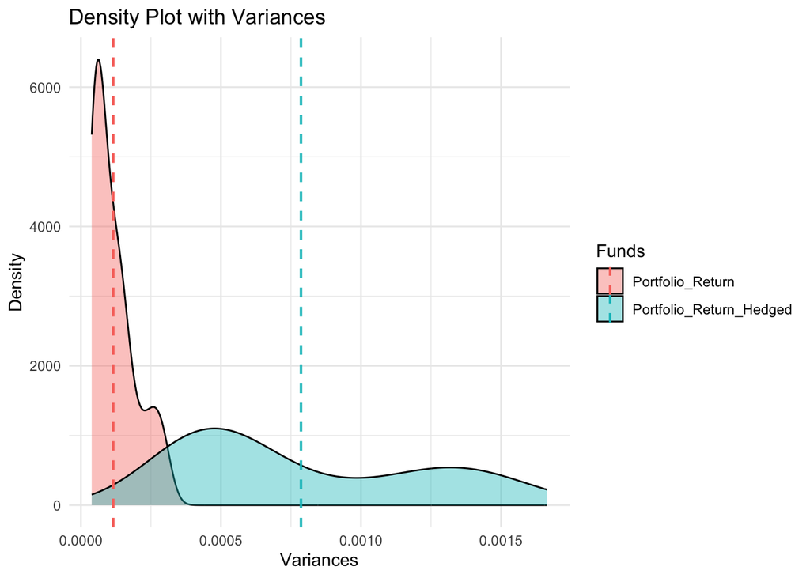

The rolling 12-month annualized return chart, combined with the annualized returns table, provides a comprehensive view of the impact of hedging on portfolio performance over time. The table shows that the Portfolio_Return_Hedged has a significantly higher annualized return (10.09%) compared to the Portfolio_Return (2.86%), highlighting the potential for higher returns when currency exposure is neutralized. However, the chart reveals the trade-off: the hedged portfolio exhibits far greater volatility, with large swings in performance, while the unhedged portfolio maintains a more stable and consistent trajectory.

```
##                   Portfolio_Return Portfolio_Return_Hedged
## Annualized Return       0.02864054               0.1008835
```

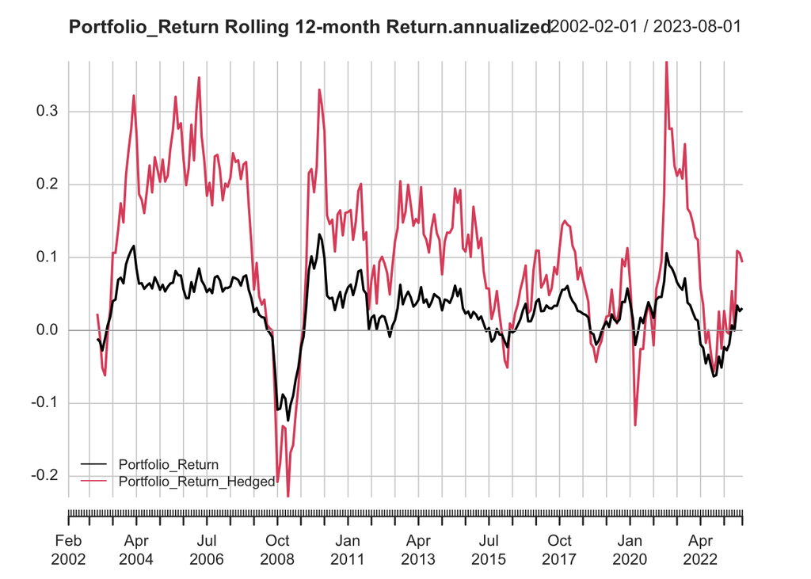

The additional plots show, that while currency hedging can lead to higher returns, it introduces significantly more volatility into the portfolio. The unhedged strategy benefits from the rand’s negative correlation with global returns, providing a natural cushion against risk and leading to more stable outcomes. These findings support the view that currency hedging should be applied tactically, driven by short-term currency forecasts, rather than as a systematic, long-term approach.